# Strongly Connected Components

Edit the RMarkdown source file for this assignment in RStudio. When you finish, Knit the file to HTML and upload the `.html` output to Canvas.

## Reversal of a graph

Consider the following graph $G$.

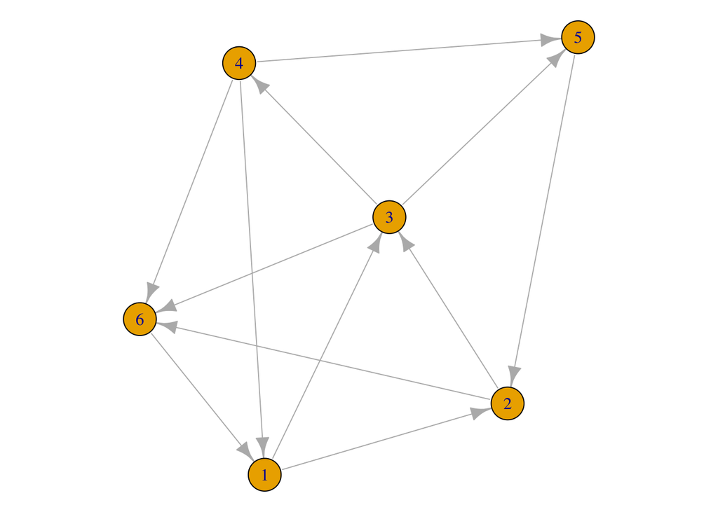

```r
library(igraph) #load the igraph library
digraph_list <- list(c(2,3),
                    c(3,6),
                    c(4,5,6),
                    c(1,5,6),
                    c(2),
                    c(1))
M <- graph_from_adj_list(digraph_list, mode="out")
```

1. Create an adjacency list for the reversal $\mbox{rev}(G)$ of the above graph $G$, and use the `igraph` package to check your answer by plotting the reversal.
2. Let `A[1..V]` be an adjacency list for a directed graph $G$, where `A[i]` is a linked list of out-neighbors of vertex `i`. Describe an algorithm for computing the adjacency list `B[1..V]` for $\mbox{rev}(G)$ in $O(V+E)$ time.

## Semiconnected graphs

A directed graph $G$ is called *semi-connected* if, for any pair of vertices $u,v$, there is a directed path from $u$ to $v$, or there is a directed path from $v$ to $u$. The following algorithm returns `True` iff the the graph `G` is semi-connected.

```
IsSemiConnected(G):
   compute scc(G)
   let v_1..v_n be a topological sort of scc(G)
   for i in 1..n
      if v_i v_[i+1] is not an edge of scc(G)
         return False
   return True
```

3. Explain why this algorithm is correct. In particular,
   1. Why is it correct to return `False` if there is no edge from `v_i` to `v_[i+1]`?
   2. Why is it correct to return `True` at the end?
4. Give the running time of the `IsSemiConnected` function as an asymptotic estimate in terms of the number of vertices $V$ and the number of edges $E$ in the graph $G$. Explain your reasoning.